# stock

## Apple Stock Price Forecast

- **Author**: [Andy Wang](https://www.linkedin.com/in/andy-wang-3b595a299/), Johns Hopkins University, Class of 2027
- **Github Repository**: https://github.com/sirandy3000/projects/tree/master/stock

## Abstract

> This Jupyter notebook contains the first part of my implementation of a stock price forecast system using machine learning. To create the system, I used Apple daily closing prices from 2022-2023 to predict prices for January 2024. I first performed Time Series Analysis on the data, considering the prices' stationarity, autocorrelation values, and trend decomposition. I then trained and evaluated several models, before finally using the best performer to create a Shiny application to allow users to forecast the stock prices of any company.

## Contents

1. Project Setup
2. Data Preprocessing
3. Time Series Analysis
4. Modeling
5. Evaluation

### 1. Project Setup

In this section, I import required packages and download the dataset.

### 1.1) Package Import

```python
import os
import urllib

import numpy as np
import pandas as pd
import matplotlib.pyplot as plt
```

```python
from tensorflow.keras.layers import Dense, LSTM
from tensorflow.keras.models import Sequential
from tensorflow.keras.utils import set_random_seed

from pmdarima import auto_arima
from prophet import Prophet

from sklearn.metrics import root_mean_squared_error
from sklearn.preprocessing import MinMaxScaler

from statsmodels.tsa.stattools import adfuller
from statsmodels.tsa.seasonal import seasonal_decompose
```

### 1.2) Data Download

I download the dataset from Yahoo Finance's [historical stock price database](https://finance.yahoo.com/quote/AAPL/history/). The dataset arrives as a single CSV file.

```python
def download_stock_data():
    url1 = "https://query1.finance.yahoo.com/v7/finance/download/"
    url2 = "AAPL?period1=1641081600&period2=1706745600&interval=1d"
    url3 = "&events=history&includeAdjustedClose=true"
    src = url1 + url2 + url3
    urllib.request.urlretrieve(url1 + url2 + url3, "stock.csv")

def load_stock_data():
    return pd.read_csv("stock.csv")
```

```python
download_stock_data()
stock = load_stock_data()
```

### 2. Data Preprocessing

In this section, I preprocess the dataset, including:

- Removing duplicate entries
- Converting features to datetime objects
- Splitting data into training and evaluation sets.

### 2.1) Dataset Information

This dataset contains 522 samples, one for each trading day from 01/2022 through 01/2024, and 7 features representing various prices, number of shares traded, and the date. Throughout this project, I use only `Date` and closing price (`Close`).

```python
stock.info()
```

```
<class 'pandas.core.frame.DataFrame'>
RangeIndex: 522 entries, 0 to 521
Data columns (total 7 columns):
 #   Column     Non-Null Count  Dtype
---  ------     --------------  -----
 0   Date       522 non-null    object
 1   Open       522 non-null    float64
 2   High       522 non-null    float64
 3   Low        522 non-null    float64
 4   Close      522 non-null    float64
 5   Adj Close  522 non-null    float64
 6   Volume     522 non-null    int64
dtypes: float64(5), int64(1), object(1)
memory usage: 28.7+ KB
```

### 2.2) Duplicate Entries

A duplicate entry is defined in this context as an extra record from any day. The dataset contains no duplicate entries to remove.

```python
stock.duplicated().sum()
```

```
0
```

### 2.3) Datetime Conversion

Values of the `Date` feature are currently stored as objects (strings) and must be converted to datetime objects.

```python
stock.Date = pd.to_datetime(stock.Date)
```

### 2.5) Train-Test Splitting

```python
train = stock.loc[(stock.Date <= "2023-09-30"), :]
valid = stock.loc[(stock.Date >= "2023-10-01")
                & (stock.Date <= "2023-12-31"), :]
test  = stock.loc[(stock.Date >= "2024-01-01"), :]
```

```python
print("There are {} training, {} validation, and {} test samples."
      .format(train.shape[0], valid.shape[0], test.shape[0]))
```

```
There are 438 training, 63 validation, and 21 test samples.
```

## 3. Time Series Analysis

In this section, I perform time series analysis to better understand the data, including:

- Determing prices' stationarity
- Calculating prices' autocorrelation values
- Decomposing prices' trend over time

### 3.1) Prices Over Time

I first graphed training prices over time to visualize any patterns models would need to recognize.

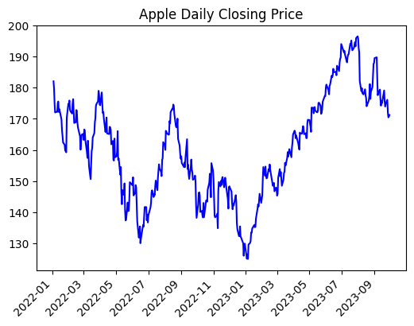

```python
price_fig, price_axs = plt.subplots(figsize=(6, 4))
price_axs.plot(train.Date, train.Close, color="b")
price_axs.set(title="Apple Daily Closing Price")
price_axs.set_xticklabels(price_axs.get_xticklabels(), rotation=45, ha="right")
plt.show()
```

### 3.2) Stationarity

Stationarity is a measure of the constancy of a time series; a stationary dataset has no seasonal patterns or trends, which could include buying/selling more shares at the beginning/end of each fiscal quarter of before/after holidays.

The Dickey-Fuller test is a common test to determine stationarity, and uses the rolling means and standard deviations of the series. The null hypothesis is "series is not stationary", while the alternative hypothesis is "series is stationary". I set a p-value threshold of 0.05: the test yielded a p-value of 0.265, indicating that the closing prices are NOT stationary.

I first visualized the rolling means and standard deviations, then performed the test.

```python
rolling_means = train.Close.rolling(24).mean()
rolling_stds  = train.Close.rolling(24).std()
```

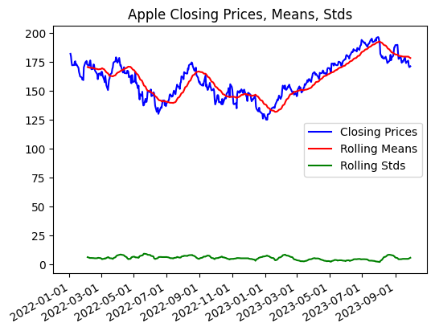

```python
pms_fig, pms_axs = plt.subplots(figsize=(6, 4))

pms_axs.plot(train.Date, train.Close,   color="b", label="Closing Prices")
pms_axs.plot(train.Date, rolling_means, color="r", label="Rolling Means")
pms_axs.plot(train.Date, rolling_stds,  color="g", label="Rolling Stds")

pms_axs.set_xticks(pms_axs.get_xticks())
pms_axs.set_xticklabels(pms_axs.get_xticklabels(), ha="right", rotation=30)
pms_axs.set_title("Apple Closing Prices, Means, Stds")
pms_axs.legend()

plt.show()
```

```python
adft = adfuller(train.Close, autolag="AIC")
```

```python
adft_df = pd.DataFrame({
    "metric": ["test_statistic", "p_value", "num_lags_used",
               "num_observations_used", "maximized_aic",
               "critical_value_1", "critical_value_5", "critical_value_10"],
    "value": [adft[0], adft[1], adft[2], adft[3], adft[5],
              adft[4]["1%"], adft[4]["5%"], adft[4]["10%"]]
})
```

```python
adft_df
```

|  | metric | value |
| --- | --- | --- |
| 0 | test_statistic | -2.049568 |
| 1 | p_value | 0.265271 |
| 2 | num_lags_used | 0.000000 |
| 3 | num_observations_used | 437.000000 |
| 4 | maximized_aic | 2096.607203 |
| 5 | critical_value_1 | -3.445403 |
| 6 | critical_value_5 | -2.868177 |
| 7 | critical_value_10 | -2.570305 |

### 3.3) Autocorrelation

Autocorrelation is correlation between a time series and its own lag; high autocorrelation values indicate that the two are correlated, i.e. that past values influence future values. The autocorrelation values between the closing prices and its 1, 2, 3, and 4-week lags are all high: buy/sell decisions are made largely based on recent market behavior.

```python
for num_weeks in np.arange(1, 5):
    print(f"{num_weeks}-week lag: {train.Close.autocorr(lag=num_weeks * 5)}")
```

```
1-week lag: 0.9263862693089397
2-week lag: 0.8532982454626523
3-week lag: 0.7848477261570374
4-week lag: 0.7304423146908646
```

### 3.4) Trend Decomposition

Decomposing the closing prices into trend, seasonality, and residuals reveals that the series' fluctuations are caused by both an irregular trend and high, unevenly distributed residuals.

I chose the fiscal quarter to be the seasonal period.

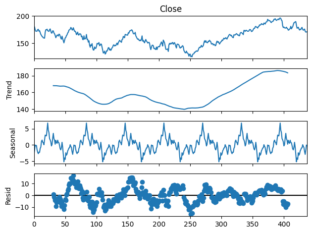

```python
num_samples_per_quarter = int(train.shape[0] / 7)
decompose = seasonal_decompose(
    train.Close, model="additive", period=num_samples_per_quarter
)
decompose.plot()
plt.show()
```

## 4. Modeling

In this section, I trained several models, then compared their performances on the validation set.

### 4.1) Helper Function

I first defined a function to plot price forecasts.

```python
def plot_forecast(forecast, model_name, axis):

    axis.plot(train.Date[-100:], train.Close[-100:], color="b", label="Training Data")
    axis.plot(valid.Date, valid.Close, color="m", label="True 2023Q4 Prices")
    axis.plot(valid.Date, forecast, color="g", label="Forecasted 2023Q4 Prices")

    axis.set(title=f"{model_name} 2023Q4 Forecast",
        ylim=(160, 200), xticks=axis.get_xticks())
    axis.set_xticklabels(axis.get_xticklabels(), ha="right", rotation=30)
    axis.legend()

    rmse = round(root_mean_squared_error(valid.Close, forecast), 3)
    axis.text(pd.to_datetime("2023-10-10"), 162, f"Forecast RMSE: {rmse}")
```

### 4.2) ARIMA

The first model was an Autoregressive Integrated Moving Average, or ARIMA. After fitting, the model simply outputted the most recent value, indicating it could not be calibrated to the training data, likely due to the data's irregular trend.

```python
arima = auto_arima(train.Close).fit(train.Close)
arima_forecast = arima.predict(n_periods=valid.Close.size)
```

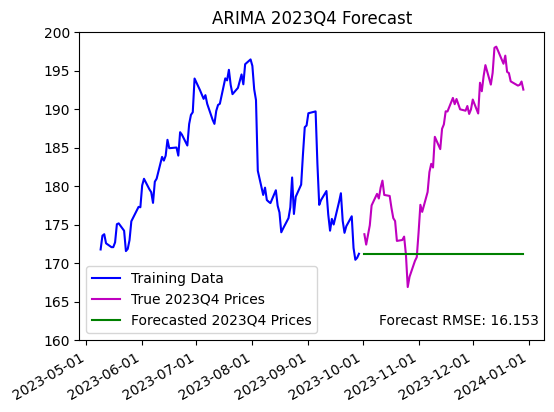

```python
arima_fig, arima_axs = plt.subplots(figsize=(6, 4))
plot_forecast(arima_forecast, "ARIMA", arima_axs)
plt.show()
```

### 4.3) Prophet

The second model was a Prophet model, designed by Meta for non-stationary series, such as the closing prices. Though it performed much better than the ARIMA, its predictions were still not ideal.

```python
prophet_train = train[["Date", "Close"]].rename({"Date": "ds", "Close": "y"}, axis=1)
prophet = Prophet().fit(prophet_train)

future_df = prophet.make_future_dataframe(periods=92)
future_pred = prophet.predict(future_df)
prophet_forecast = future_pred.loc[future_df.ds.isin(valid.Date), "yhat"]
```

```
20:37:13 - cmdstanpy - INFO - Chain [1] start processing
20:37:13 - cmdstanpy - INFO - Chain [1] done processing
```

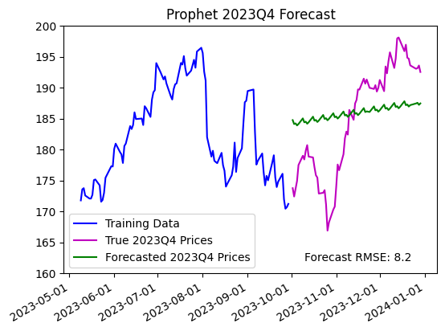

```python
prop_fig, prop_axs = plt.subplots(figsize=(6, 4))
plot_forecast(prophet_forecast, "Prophet", prop_axs)
plt.show()
```

### 4.4) LSTM

The final model is an LSTM neural network, which I chose for its ability to prioritize "recent" data over "older" data when making predictions. I trained the model to predict each day's price using the prices from its past 60 days. This model had by far the best performance.

```python
NUM_DAYS_BEFORE = 60
```

Before fitting the model, I scaled the training set, then split it into feature matrix `X_train` and target vector `y_train` such that for each price in `y_train`, its corresponding vector in `X_train` consists of the 60 prices before it.

```python
scaler = MinMaxScaler()
train_ = train[["Close"]].copy()
train_ = scaler.fit_transform(train_).flatten()
```

```python
X_train_, y_train_ = [], []
for i in range(NUM_DAYS_BEFORE, len(train_)):
    X_train_.append(train_[i - NUM_DAYS_BEFORE:i])
    y_train_.append(train_[i])

X_train_, y_train_ = np.array(X_train_), np.array(y_train_)
X_train_ = X_train_.reshape(
    X_train_.shape[0], X_train_.shape[1], 1
)
```

```python
set_random_seed(42)

lstm = Sequential()
lstm.add(LSTM(units=50, return_sequences=True, input_shape=(60, 1)))
lstm.add(LSTM(units=50))
lstm.add(Dense(1))

lstm.compile(loss="mean_squared_error", optimizer="adam")
history = lstm.fit(X_train_, y_train_, epochs=10, batch_size=1, verbose=0)
```

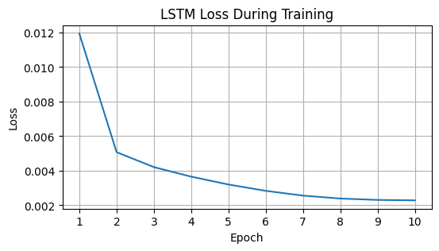

```python
epochs = np.arange(10) + 1
loss_fig, loss_axs = plt.subplots(figsize=(6, 3))

loss_axs.plot(epochs, history.history["loss"])
loss_axs.set(title="LSTM Loss During Training",
    xlabel="Epoch", ylabel="Loss", xticks=epochs)

loss_axs.grid()
plt.show()
```

To predict on the validation set, I manipulated the validation set in the same way as the training set.

```python
valid_ = pd.concat([train, valid])
valid_ = valid_[len(train) - NUM_DAYS_BEFORE:][["Close"]]
valid_ = scaler.transform(valid_).flatten()
```

```python
X_valid_ = []
for i in range(NUM_DAYS_BEFORE, len(valid_)):
    X_valid_.append(valid_[i - NUM_DAYS_BEFORE:i])

X_valid_ = np.array(X_valid_)
X_valid_ = X_valid_.reshape(
    X_valid_.shape[0], X_valid_.shape[1], 1
)
```

```python
y_valid_ = lstm.predict(X_valid_)
lstm_forecast = scaler.inverse_transform(y_valid_)
```

```
2/2 ━━━━━━━━━━━━━━━━━━━━ 1s 622ms/step
```

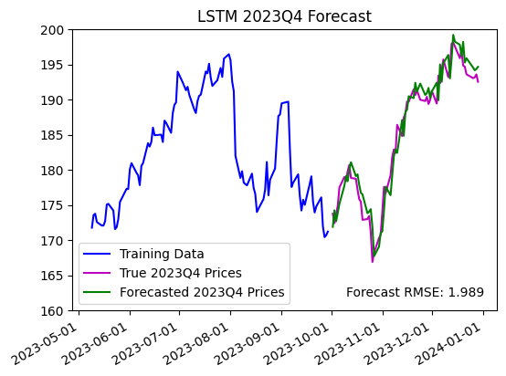

```python
lstm_fig, lstm_axs = plt.subplots(figsize=(6, 4))
plot_forecast(lstm_forecast, "LSTM", lstm_axs)
plt.show()
```

## 5. Evaluation

In this section, I retrained the best performing model on the combined training-validation set, then evaluated this final model on the evaluation set.

```python
scaler_ = MinMaxScaler()
train_valid_  = pd.concat([train, valid])[["Close"]]
train_valid_  = scaler_.fit_transform(train_valid_).flatten()
```

```python
X_train_valid_, y_train_valid_ = [], []
for i in range(NUM_DAYS_BEFORE, len(train_valid_)):
    X_train_valid_.append(train_valid_[i - NUM_DAYS_BEFORE:i])
    y_train_valid_.append(train_valid_[i])

X_train_valid_, y_train_valid_ = np.array(X_train_valid_), np.array(y_train_valid_)
X_train_valid_ = X_train_valid_.reshape(
    X_train_valid_.shape[0], X_train_valid_.shape[1], 1
)
```

```python
lstm_ = Sequential()
lstm_.add(LSTM(units=50, return_sequences=True,
    input_shape=(X_train_valid_.shape[1], 1)))
lstm_.add(LSTM(units=50))
lstm_.add(Dense(1))

lstm_.compile(loss="mean_squared_error", optimizer="adam")
history_ = lstm_.fit(X_train_valid_, y_train_valid_, epochs=10, batch_size=1, verbose=0)
```

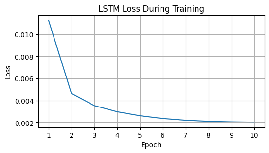

```python
epochs = np.arange(10) + 1
loss_fig_, loss_axs_ = plt.subplots(figsize=(6, 3))

loss_axs_.plot(epochs, history_.history["loss"])
loss_axs_.set(title="LSTM Loss During Training",
    xlabel="Epoch", ylabel="Loss", xticks=epochs)

loss_axs_.grid()
plt.show()
```

```python
test_ = pd.concat([valid, test])
test_ = test_[len(valid) - 60:][["Close"]]
test_ = scaler_.transform(test_).flatten()
```

```python
X_test_ = []
for i in range(60, len(test_)):
    X_test_.append(test_[i - 60:i])

X_test_ = np.array(X_test_)
X_test_ = X_test_.reshape(
    X_test_.shape[0], X_test_.shape[1], 1
)
```

```python
y_test_ = lstm_.predict(X_test_)
lstm_forecast_ = scaler_.inverse_transform(y_test_)
```

```
1/1 ━━━━━━━━━━━━━━━━━━━━ 1s 687ms/step
```

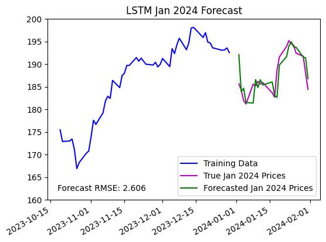

```python
lstm_fig_, lstm_axs_ = plt.subplots(figsize=(6, 4))

lstm_axs_.plot(valid.Date[-50:], valid.Close[-50:], color="b", label="Training Data")
lstm_axs_.plot(test.Date, test.Close, color="m", label="True Jan 2024 Prices")
lstm_axs_.plot(test.Date, lstm_forecast_, color="g", label="Forecasted Jan 2024 Prices")

lstm_axs_.set(title=f"LSTM Jan 2024 Forecast",
    ylim=(160, 200), xticks=lstm_axs_.get_xticks())
lstm_axs_.set_xticklabels(lstm_axs_.get_xticklabels(), ha="right", rotation=30)
lstm_axs_.legend()

rmse = round(root_mean_squared_error(test.Close, lstm_forecast_), 3)
lstm_axs_.text(pd.to_datetime("2023-10-18"), 162, f"Forecast RMSE: {rmse}")

plt.show()
```

The final model performed 31% worse on the evaluation set than on the validation set, indicating that it generalizes fairly well and did not severely overfit.

```python
valid_rmse = root_mean_squared_error(valid.Close, lstm_forecast)
test_rmse = root_mean_squared_error(test.Close, lstm_forecast_)

gen_error = (test_rmse - valid_rmse) / valid_rmse
print(f"The model performs {round(gen_error *100, 2)}% worse on the evaluation set.")
```

```
The model performs 31.04% worse on the evaluation set.
```